# Vertical movement analysis

Pieterjan Verhelst (pieterjan.verhelst@inbo.be)

17-2-2022

## Background

Eels were tracked from the Belgian coast (Nieuwpoort) through the North Sea as they migrate to their spawning grounds in the Atlantic Ocean. See [our article](https://www.nature.com/articles/s41598-021-04052-7) for the migration routes. In brief, the routes were modeled through geolocation modelling based on logged data on temperature and depth obtained by data loggers that were externally attached to the eels. For more info on the method, we refer to the aforementioned article. In general, we found that the eels can take 2 routes: a northern route over the UK or a southern route through the English Channel.

Now that we analysed the horizontal movement patterns (i.e. the migration routes), we want to analyse the vertical movement patterns. This can provide information on how eels orient themselves or move in a bio-energetic efficient way. Two of our key questions is if the eels have a circadian pattern in their vertical movement and if they apply selective tidal stream transport (STST). It is known that eels apply a diel vertical migration pattern in the Atlantic Ocean: they dive to depths of ca. 800 m during daytime, but swim at depths of ca. 200 m during night time (see [this article](https://www.science.org/doi/abs/10.1126/science.1178120)). However, it is unknown if eels show this or another pattern on the shallow continental shelf. Considering STST, this mode of transport has been illustrated for eels in [estuaries](https://www.sciencedirect.com/science/article/abs/pii/S0272771418304530). Since the North Sea and the English Channel have strong prevailing tidal currents, it is plausible that eels apply STST as well and hence behave differently during the ebbing and flooding tide. To gain more insight in the vertical movement pattern, we want to analyse the eel’s swimming depth (**depth measurements every 5 minutes**) over time in relation to the next relevant explanatory variables, being:

- **Eastward current velocity (m/s) U** * → Obtained from tidal model
- **Northward current velocity (m/s) V** * → Obtained from tidal model
- **Water temperature (°C)** → Measured by data loggers
- **Illuminated moon fraction (percentage)** → Obtained from suncalc R-package
- **Day or night** → Obtained from suncalc R-package
- **Sun altitude** → Obtained from suncalc R-package
- **Sun azimuth** → Obtained from suncalc R-package

*Water currents are calculated as eastward and northward velocity vectors. Since the eels took 2 routes, I would split up the analysis for eels taking the southern route and eels taking the northern route.

## Set time zone

```r
Sys.setenv(TZ='GMT')
Sys.timezone()
```

```
## [1] "GMT"
```

## Load packages

```r
library(tidyverse)
library(lubridate)
library(mgcv)
#library(splines) # for bs function
#library(REdaS)
library(car)
```

```r
#library(sjPlot)
#library(EnvStats)
library(pracma)
library(nlme) # for gls()
library(gridExtra)
library(forecast) # for auto.arima() function
library(tseries) # for Augmented Dickey-Fuller Test (adf.test())
library(visreg)
library(itsadug)
```

## Load dataset of 42 eels and set columns

```r
data <- read.csv("./data/interim/data_circadian_tidal_moon_sun_5min.csv")
data$ID <- factor(data$ID)
data$datetime <- ymd_hms(data$datetime)
data$night_day <- factor(data$night_day)
data <- data %>%
            rename(direction_x = U,
                   direction_y = V)
```

## Subset 1 eel for testing

```r
data_1eel <- filter(data, ID == "16031")
```

## ACF plot

Create an autocorrelation function plot to explore the cyclic signals in the data. The horizontal blue lines in the plot indicate the confidence interval in the correlogram. First create plot for total dataset.

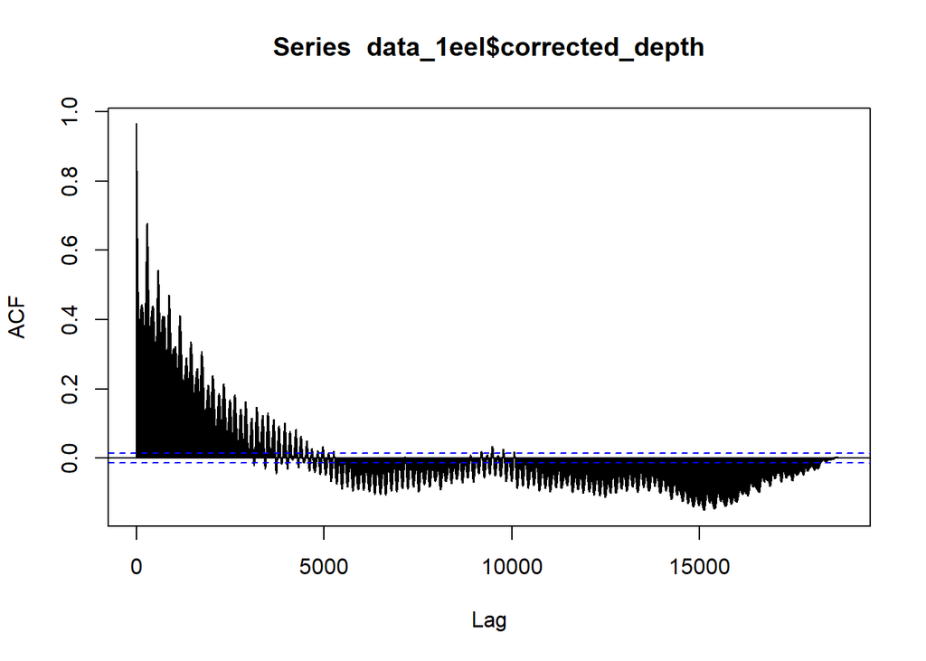

```r
forecast::Acf(data_1eel$corrected_depth, type = c("correlation"), lag.max=max(dim(data_1eel)), plot = TRUE)
```

Next, create the ACF plot for the first 500 observations.

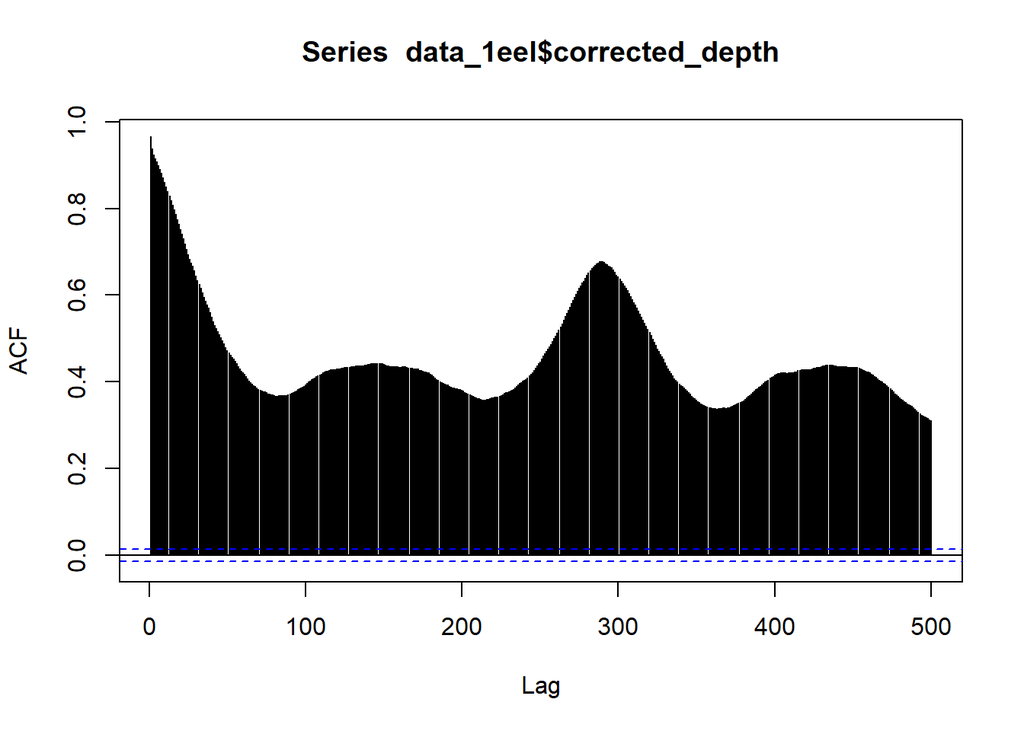

```r
forecast::Acf(data_1eel$corrected_depth, type = c("correlation"), lag.max=500, plot = TRUE)
```

In the plot above, we see 2 cycles subsequently returning. The first is probably related to a tidal signal, as it occurs ca. every 12 hours at lag 144: (12 hours x 60 minutes) / 5 minutes = 144

The second is probably related to a circadian rythm with a 24 h pattern at ca. lag 288: (24 hours x 60 minutes) / 5 minutes = 288

To illustrate this, we added a green vertical line at lag 144 and a blue line at lag 288 to the plot.

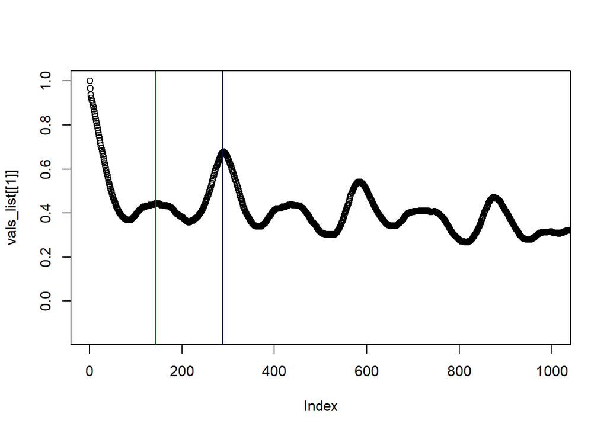

```r
vals_list <- forecast::Acf(data_1eel$corrected_depth, type = c("correlation"), lag.max=max(dim(data_1eel)), plot = FALSE)
plot(vals_list[[1]], xlim=c(0, 1000))
abline(v = 144, col = "darkgreen")
abline(v = 288, col = "darkblue")
```

## Depth data processing

The depth sensors are not 100% accurate. Hence, it can occur that when an eel is swimming close to the surface, the depth sensor registers a value as if the eel would be above the surface. Also, the depth sensors drift over time. A linear regression between the start of data logging (= when the tag was at zero atmospheric pressure) and the moment the tag surfaced (= when the tag was again at zero atmospheric pressure) was conducted at an earlier stage (to generate the trajectories). Hence the variable name ‘corrected’ depth.

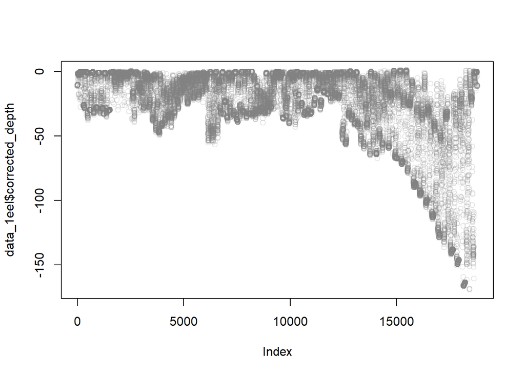

```r
plot(data_1eel$corrected_depth, col = rgb(red = 0.5, green = 0.5, blue = 0.5, alpha = 0.2))
```

```r
summary(data_1eel$corrected_depth)
```

```
##     Min.  1st Qu.   Median     Mean  3rd Qu.     Max.
## -169.184  -32.699  -17.962  -26.144   -4.303    1.078
```

## Add daily max depth to dataset

```r
data_max_depth <- data_1eel %>%
  group_by(ID, Date) %>%
  summarise(max_depth = min(corrected_depth))
```

[output not shown]

```r
data_1eel <- left_join(data_1eel, data_max_depth, by = c("ID","Date"))
```

# Add daily bathymetry based on the trajectory files obtained from the geolocation models

```r
# Link trajectory data (source trajectory data script)
tr_data <- read_csv("./data/external/trajectory_data/eel_trajectories.csv")
# Select columns
tr_data <- dplyr::select(tr_data, ID, Date, Max_Depth)
tr_data <- rename(tr_data,
                  max_depth_bathymetry = Max_Depth)

# Process columns
tr_data$Date <- dmy(tr_data$Date)
tr_data$ID <- factor(tr_data$ID)

# Remove double dates per eel (ID)
#tr_data <- tr_data[!duplicated(tr_data[c('ID','Date')]),]
tr_data <- tr_data %>%     # Add ID number to duplicate dates
  group_by(ID, Date) %>%
  add_tally()

duplicates <- filter(tr_data, n == 2)   # Filter duplicate dates
duplicates <- duplicates %>%             # Add ID number to distinguish between first and second duplicate
  mutate(number_id = row_number())
duplicates <- filter(duplicates, number_id == 2)  # Filter second duplicates

tr_data <- filter(tr_data, n != 2)   # Remove duplicate dates from tracking dataset

# Bind 'duplicates' dataset with second duplicates to tracking dataset
tr_data <- ungroup(tr_data)
tr_data$n <- NULL
duplicates <- ungroup(duplicates)
duplicates$n <- NULL
duplicates$number_id <- NULL

tr_data <- rbind(tr_data, duplicates)

# Select relevant eels
tr_data <- filter(tr_data, ID == "16031" )
tr_data$ID <- factor(tr_data$ID) # rerun 'factor()' so the number of levels is set accurately

data_1eel$Date <- as.Date(data_1eel$Date)
data_1eel <- left_join(data_1eel, tr_data, by = c('ID', 'Date'))

# Remove line with max depth bathymetry > 300 m --> remove location in deep sea
data_1eel$max_depth_bathymetry <- -1*(as.numeric(data_1eel$max_depth_bathymetry))
data_1eel <- filter(data_1eel, max_depth_bathymetry >= -300)
```

Plot the daily depth range, the max depth and the max depth bathymetry. The latter 2 do not differ a lot because one of the assumptions in the geolocation model is that the eel’s daily depth is the daily max bathymetry.

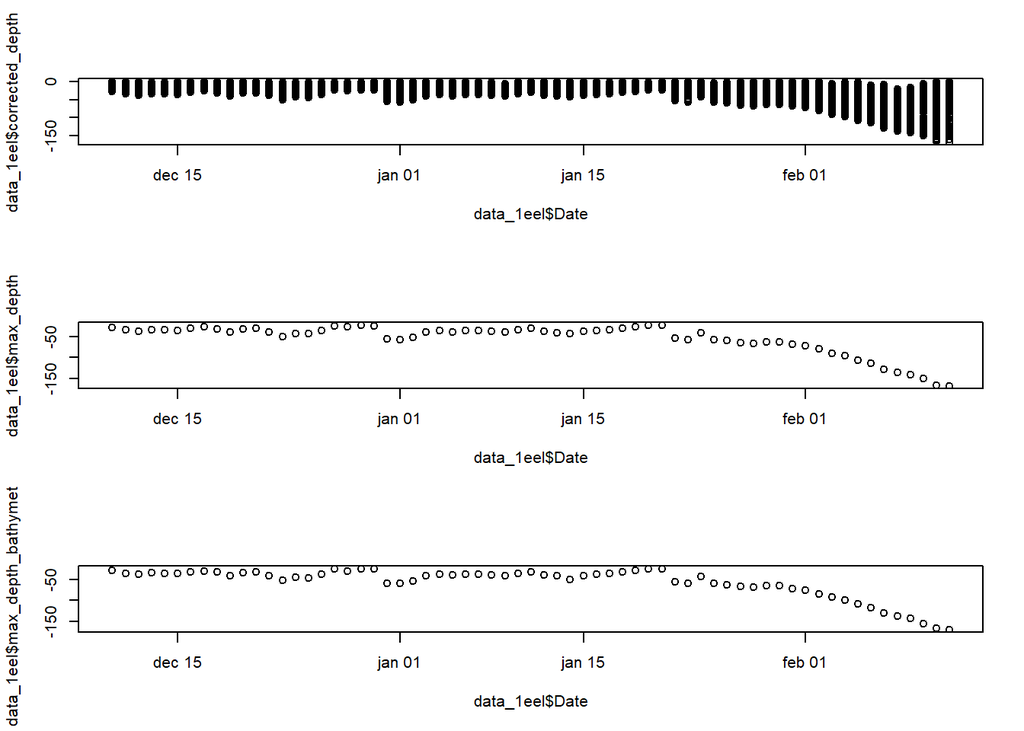

Three depth variables over time for 1 eel: corrected swimming depth, daily maximum depth and the daily maximum bathymetry obtained via the geolocation model.

```r
par(mfrow=c(3,1))
plot(data_1eel$Date, data_1eel$corrected_depth)
plot(data_1eel$Date, data_1eel$max_depth)
plot(data_1eel$Date, data_1eel$max_depth_bathymetry)
```

## Calculate the relative depth

Eels are known to reside near the bottom. Therefore, it can be reasonably assumed that the daily max swimming depth corresponds with the max daily bathymetry. Hence, the relative depth is calculated as the swimming depth divided by the max depth of that day.

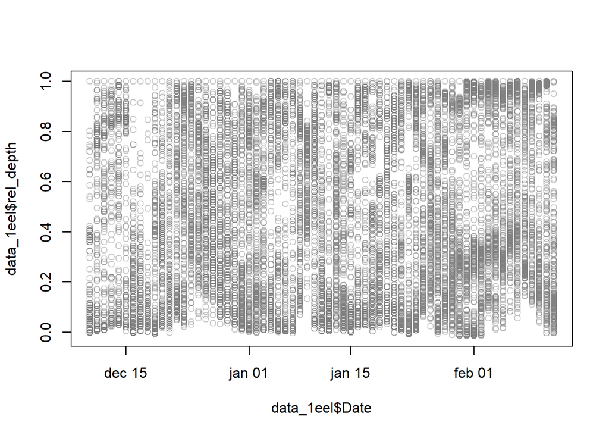

Plot of the relative depth for 1 eel.

```r
data_1eel$rel_depth <- data_1eel$corrected_depth / data_1eel$max_depth
plot(data_1eel$Date, data_1eel$rel_depth, col = rgb(red = 0.5, green = 0.5, blue = 0.5, alpha = 0.4))
```

## Exploratory plots

### Vertical depth pattern over time

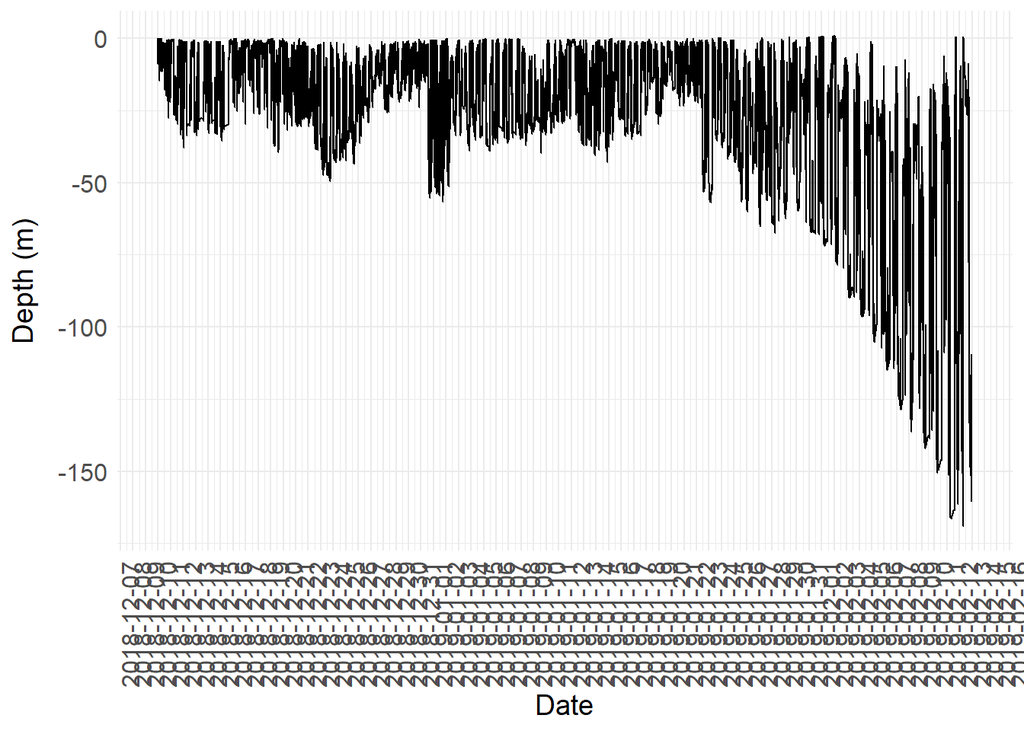

Vertical movement pattern for 1 eel.

```r
ggplot(data_1eel, aes(x = datetime,
                                   y = corrected_depth)) +
  geom_line() +
  theme_minimal() +
  ylab("Depth (m)") +
  xlab("Date") +
  theme(axis.title.y = element_text(margin = margin(r = 10))) +
  theme(axis.text.x = element_text(angle = 90, hjust = 1)) +
  theme(axis.text = element_text(size = 12),
        axis.title = element_text(size = 14)) +
  scale_x_datetime(date_breaks  = "1 day")
```

### Plot detail of vertical movement behaviour

In this plot a distinctive behaviour can be observed between day and night; the vertical red line indicates midnight. During the daytime, the eels have a steady depth, while at night they have a higher vertical amplitude in the water column. Also, there are moments where the eel remains near the bottom which I think is attributed to the tides.

```r
data_1eel_10days <- filter(data_1eel,datetime >= "2019-02-01 00:00:00", datetime <= "2019-02-11 00:00:00")

# Create line every 24 hours
gnu <-  seq.POSIXt(from = lubridate::floor_date(data_1eel_10days$datetime[1], "day"), to= data_1eel_10days$datetime[nrow(data_1eel_10days)], by = 86400)
class(lubridate::floor_date(data_1eel_10days$datetime[1], "day"))
```

```
## [1] "POSIXct" "POSIXt"
```

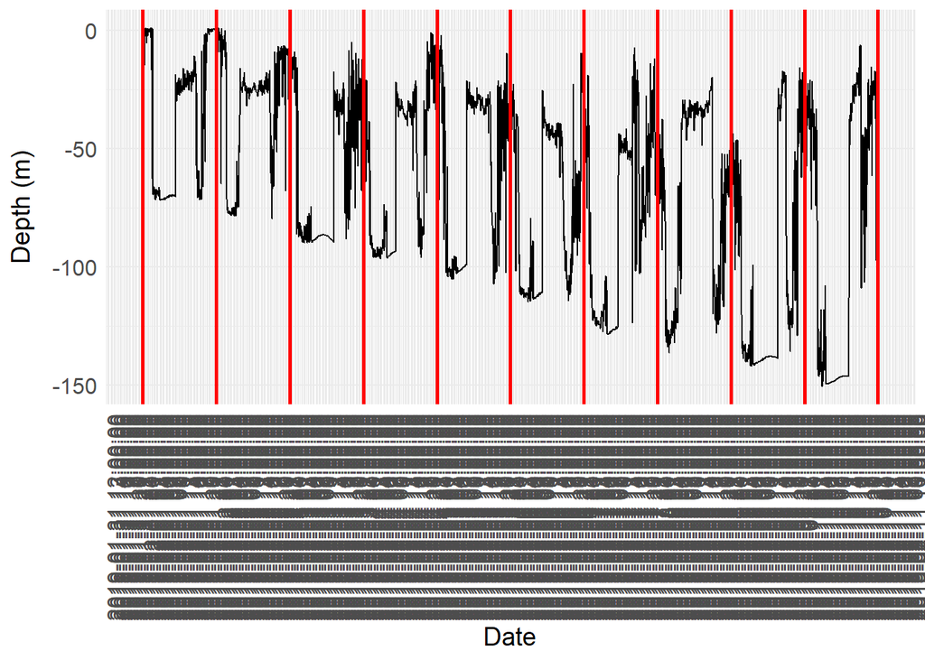

10-day detail of the vertical movement pattern for 1 eel.

```r
ggplot(data_1eel_10days, aes(x = datetime,
                                       y = corrected_depth)) +
  geom_line() +
  theme_minimal() +
  ylab("Depth (m)") +
  xlab("Date") +
  theme(axis.title.y = element_text(margin = margin(r = 10))) +
  theme(axis.text.x = element_text(angle = 90, hjust = 1)) +
  theme(axis.text = element_text(size = 12),
        axis.title = element_text(size = 14)) +
  scale_x_datetime(date_breaks  ="1 hour") +
  geom_vline(xintercept=gnu, color = "red", size = 1)
```

### Relative depth over time

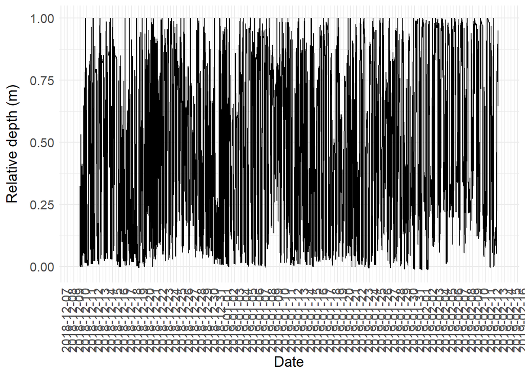

The relative depth for 1 eel.

```r
ggplot(data_1eel, aes(x = datetime,
                                   y = rel_depth)) +
  geom_line() +
  theme_minimal() +
  ylab("Relative depth (m)") +
  xlab("Date") +
  theme(axis.title.y = element_text(margin = margin(r = 10))) +
  theme(axis.text.x = element_text(angle = 90, hjust = 1)) +
  theme(axis.text = element_text(size = 12),
        axis.title = element_text(size = 14)) +
  scale_x_datetime(date_breaks  = "1 day")
```

### Plot detail of relative depth

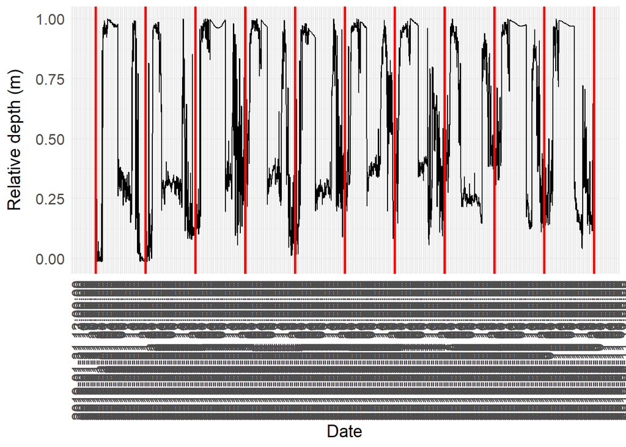

10-day detail of the relative depth for 1 eel.

```r
ggplot(data_1eel_10days, aes(x = datetime,
                                       y = rel_depth)) +
  geom_line() +
  theme_minimal() +
  ylab("Relative depth (m)") +
  xlab("Date") +
  theme(axis.title.y = element_text(margin = margin(r = 10))) +
  theme(axis.text.x = element_text(angle = 90, hjust = 1)) +
  theme(axis.text = element_text(size = 12),
        axis.title = element_text(size = 14)) +
  scale_x_datetime(date_breaks  ="1 hour") +
  geom_vline(xintercept=gnu, color = "red", size = 1)
```

### Temperature over time

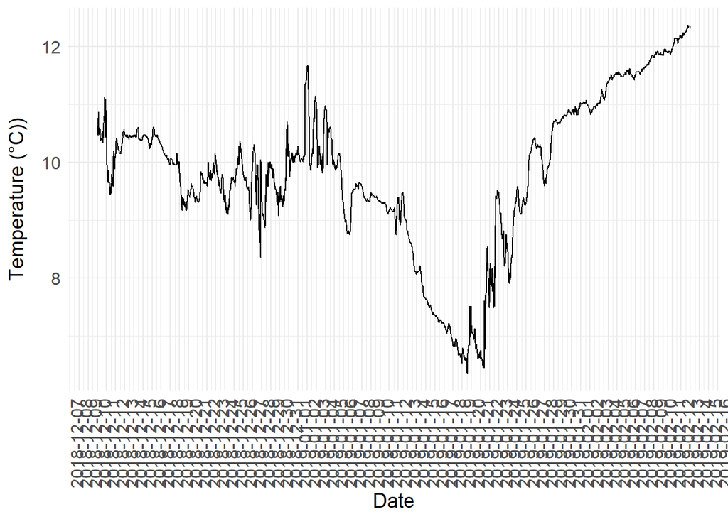

Water temperature pattern for 1 eel.

```r
ggplot(data_1eel, aes(x = datetime,
                                 y = temperature)) +
  geom_line() +
  theme_minimal() +
  ylab("Temperature (°C))") +
  xlab("Date") +
  theme(axis.title.y = element_text(margin = margin(r = 10))) +
  theme(axis.text.x = element_text(angle = 90, hjust = 1)) +
  theme(axis.text = element_text(size = 12),
        axis.title = element_text(size = 14)) +
  scale_x_datetime(date_breaks  = "1 day")
```

### Plot detail of temperature

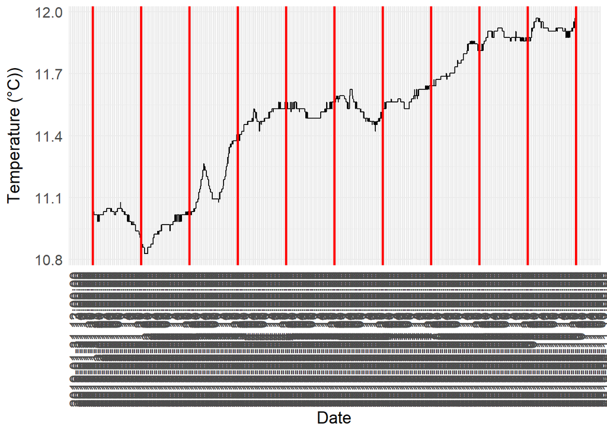

10-day detail of the water temperature pattern for 1 eel.

```r
ggplot(data_1eel_10days, aes(x = datetime,
                                   y = temperature)) +
  geom_line() +
  theme_minimal() +
  ylab("Temperature (°C))") +
  xlab("Date") +
  theme(axis.title.y = element_text(margin = margin(r = 10))) +
  theme(axis.text.x = element_text(angle = 90, hjust = 1)) +
  theme(axis.text = element_text(size = 12),
        axis.title = element_text(size = 14)) +
  scale_x_datetime(date_breaks  ="1 hour") +
  geom_vline(xintercept=gnu, color = "red", size = 1)
```

### Plot relative depth over temperature

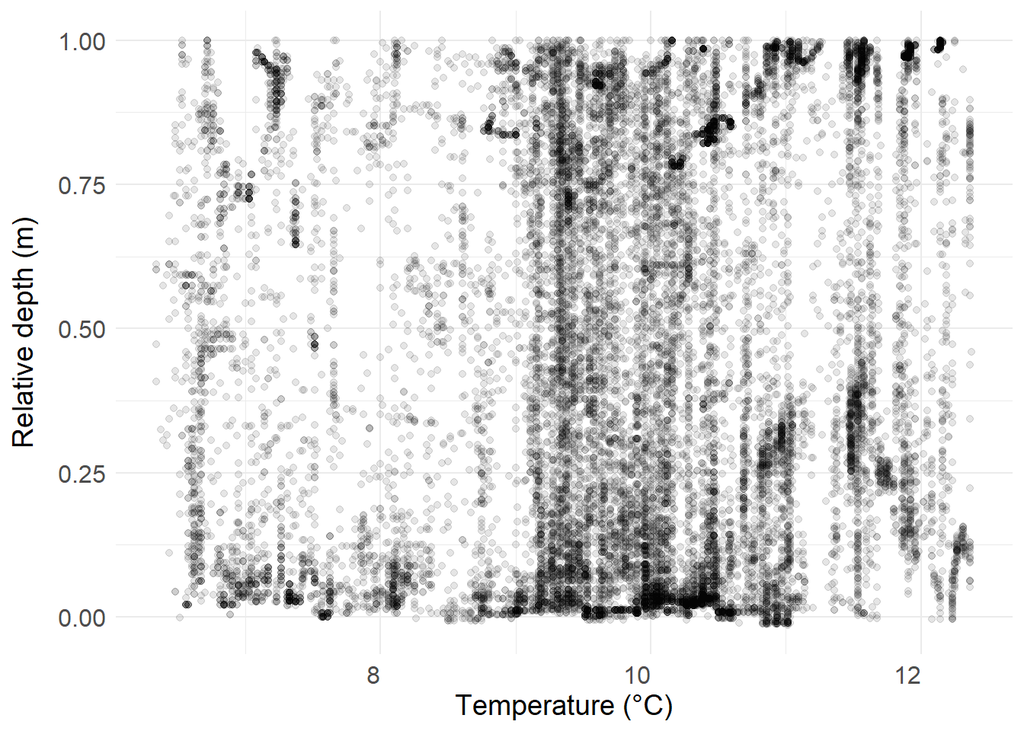

Relative depth over temperature for 1 eel.

```r
ggplot(data_1eel, aes(x = temperature,
                                 y = rel_depth)) +
  geom_point(alpha = 0.1) +
  theme_minimal() +
  ylab("Relative depth (m)") +
  xlab("Temperature (°C)") +
  theme(axis.title.y = element_text(margin = margin(r = 10))) +
  theme(axis.text.x = element_text(hjust = 1)) +
  theme(axis.text = element_text(size = 12),
        axis.title = element_text(size = 14))
```

### Plot detail relative depth over temperature

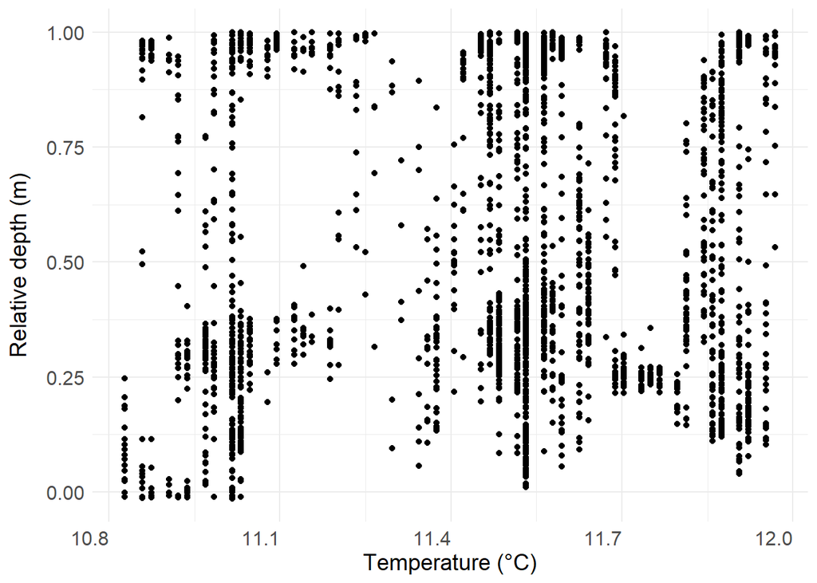

10-day detail of the relative depth over temperature pattern for 1 eel.

```r
ggplot(data_1eel_10days, aes(x = temperature,
                                 y = rel_depth)) +
  geom_point() +
  theme_minimal() +
  ylab("Relative depth (m)") +
  xlab("Temperature (°C)") +
  theme(axis.title.y = element_text(margin = margin(r = 10))) +
  theme(axis.text.x = element_text(hjust = 1)) +
  theme(axis.text = element_text(size = 12),
        axis.title = element_text(size = 14))
```

### Plot bathymetry over time

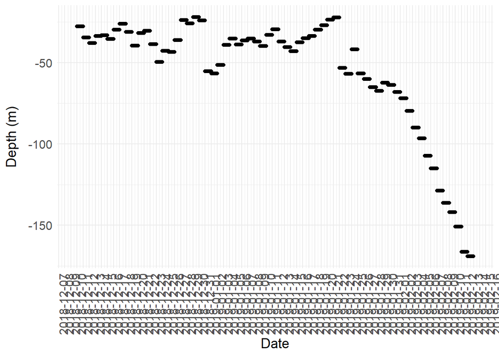

Daily max depth for 1 eel.

```r
ggplot(data_1eel, aes(x = datetime,
                                 y = max_depth)) +
  geom_point() +
  theme_minimal() +
  ylab("Depth (m)") +
  xlab("Date") +
  theme(axis.title.y = element_text(margin = margin(r = 10))) +
  theme(axis.text.x = element_text(angle = 90, hjust = 1)) +
  theme(axis.text = element_text(size = 12),
        axis.title = element_text(size = 14)) +
  scale_x_datetime(date_breaks  = "1 day")
```

### Plot vertical depth pattern over bathymetry

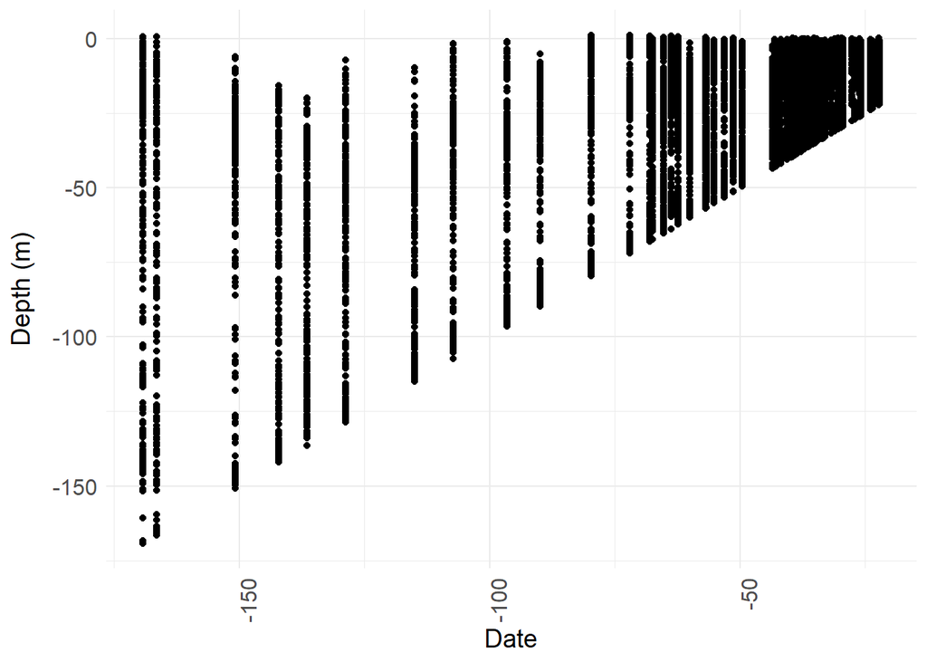

Vertical movement pattern over the daily max depth for 1 eel.

```r
ggplot(data_1eel, aes(x = max_depth,
                                 y = corrected_depth)) +
  geom_point() +
  theme_minimal() +
  ylab("Depth (m)") +
  xlab("Date") +
  theme(axis.title.y = element_text(margin = margin(r = 10))) +
  theme(axis.text.x = element_text(angle = 90, hjust = 1)) +
  theme(axis.text = element_text(size = 12),
        axis.title = element_text(size = 14))
```

### Plot relative depth over eastward current velocity vector

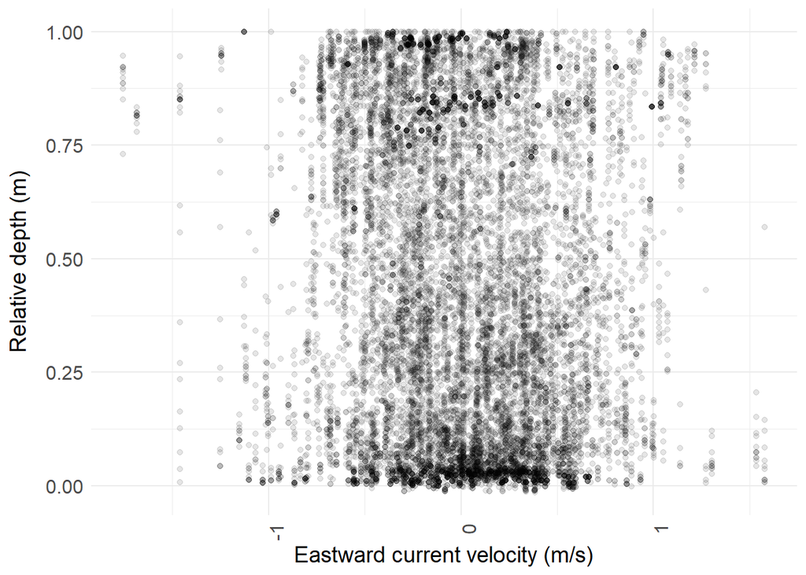

Relative depth over eastward current velocity for 1 eel.

```r
ggplot(data_1eel, aes(x = direction_x,
                                       y = rel_depth)) +
  geom_point(alpha = 0.1) +
  theme_minimal() +
  ylab("Relative depth (m)") +
  xlab("Eastward current velocity (m/s)") +
  theme(axis.title.y = element_text(margin = margin(r = 10))) +
  theme(axis.text.x = element_text(angle = 90, hjust = 1)) +
  theme(axis.text = element_text(size = 12),
        axis.title = element_text(size = 14))
```

### Plot detail relative depth over eastward current velocity vector

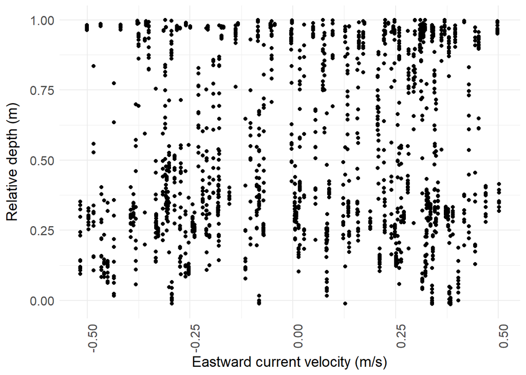

10-day detail of the relative depth over eastward current velocity for 1 eel.

```r
ggplot(data_1eel_10days, aes(x = direction_x,
                                       y = rel_depth)) +
  geom_point() +
  theme_minimal() +
  ylab("Relative depth (m)") +
  xlab("Eastward current velocity (m/s)") +
  theme(axis.title.y = element_text(margin = margin(r = 10))) +
  theme(axis.text.x = element_text(angle = 90, hjust = 1)) +
  theme(axis.text = element_text(size = 12),
        axis.title = element_text(size = 14))
```

### Plot relative depth over northward current velocity vector

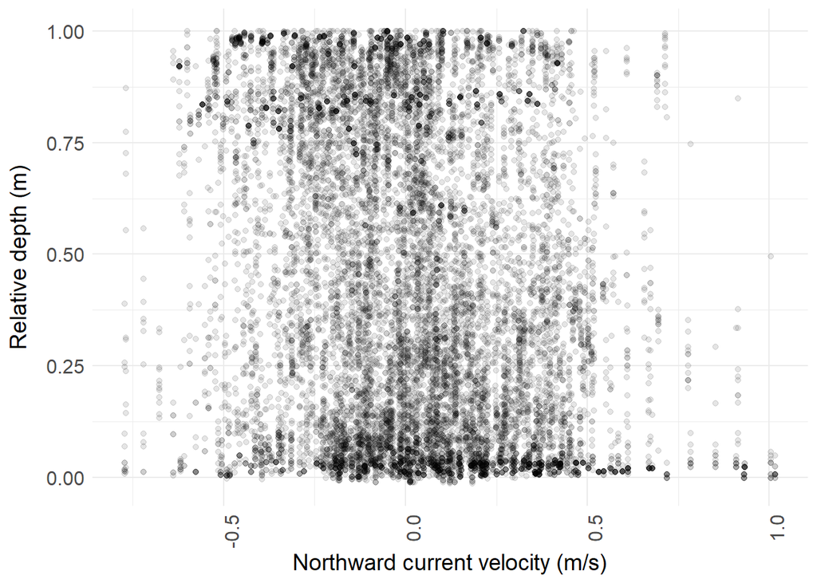

Relative depth over northward current velocity for 1 eel.

```r
ggplot(data_1eel, aes(x = direction_y,
                                   y = rel_depth)) +
  geom_point(alpha = 0.1) +
  theme_minimal() +
  ylab("Relative depth (m)") +
  xlab("Northward current velocity (m/s)") +
  theme(axis.title.y = element_text(margin = margin(r = 10))) +
  theme(axis.text.x = element_text(angle = 90, hjust = 1)) +
  theme(axis.text = element_text(size = 12),
        axis.title = element_text(size = 14))
```

### Plot detail relative depth over northward current velocity vector

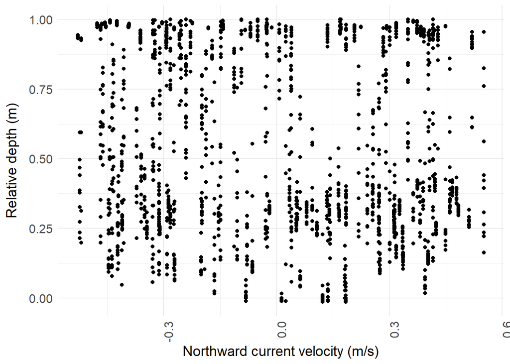

10-day detail of the relative depth over northward current velocity for 1 eel.

```r
ggplot(data_1eel_10days, aes(x = direction_y,
                                   y = rel_depth)) +
  geom_point() +
  theme_minimal() +
  ylab("Relative depth (m)") +
  xlab("Northward current velocity (m/s)") +
  theme(axis.title.y = element_text(margin = margin(r = 10))) +
  theme(axis.text.x = element_text(angle = 90, hjust = 1)) +
  theme(axis.text = element_text(size = 12),
        axis.title = element_text(size = 14))
```

### Plot relative depth pattern over day and night

Note that there is not a big difference because the depth range between day and night is equal, but the pattern is not.

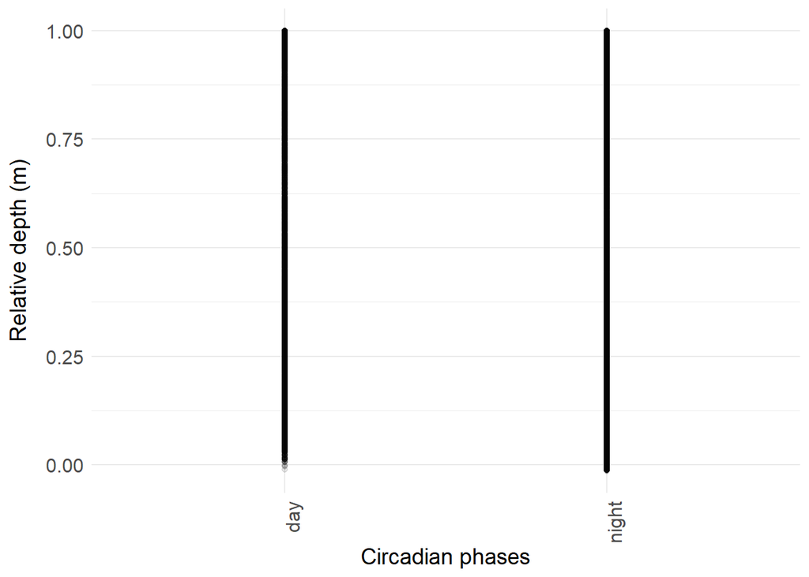

Relative depth during daytime and at night for 1 eel.

```r
ggplot(data_1eel, aes(x = night_day,
                                   y = rel_depth)) +
  geom_point(alpha = 0.1) +
  theme_minimal() +
  ylab("Relative depth (m)") +
  xlab("Circadian phases") +
  theme(axis.title.y = element_text(margin = margin(r = 10))) +
  theme(axis.text.x = element_text(angle = 90, hjust = 1)) +
  theme(axis.text = element_text(size = 12),
        axis.title = element_text(size = 14))
```

### Plot relative depth pattern over illuminated moon phase

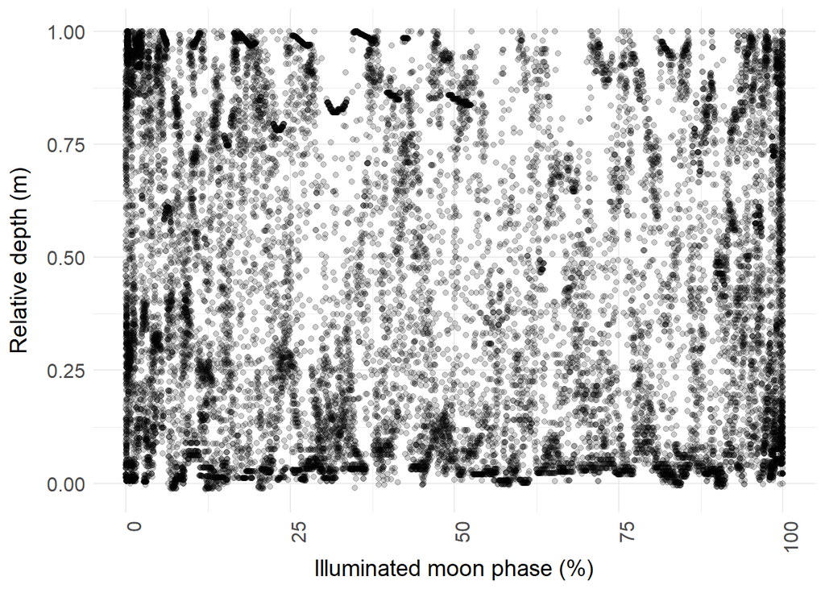

Relative depth over illuminated fraction of the moon for 1 eel.

```r
ggplot(data_1eel, aes(x = 100*moon_fraction,
                                   y = rel_depth)) +
  geom_point(alpha = 0.2) +
  theme_minimal() +
  ylab("Relative depth (m)") +
  xlab("Illuminated moon phase (%)") +
  theme(axis.title.y = element_text(margin = margin(r = 10))) +
  theme(axis.text.x = element_text(angle = 90, hjust = 1)) +
  theme(axis.text = element_text(size = 12),
        axis.title = element_text(size = 14))
```

### Plot detail relative depth pattern over illuminated moon phase

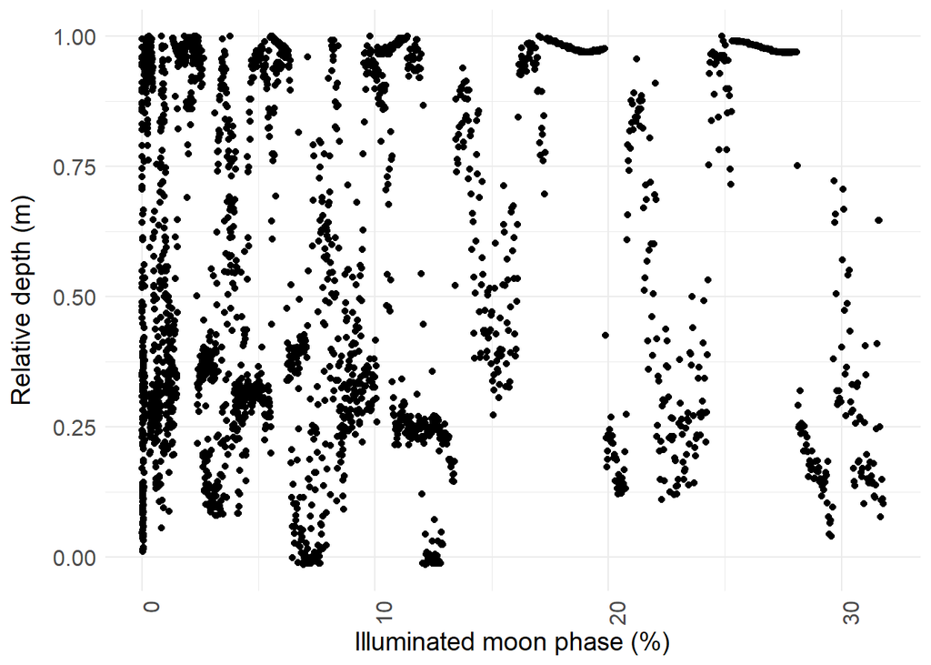

10-day detail of the relative depth over illuminated fraction of the moon for 1 eel.

```r
ggplot(data_1eel_10days, aes(x = 100*moon_fraction,
                                   y = rel_depth)) +
  geom_point() +
  theme_minimal() +
  ylab("Relative depth (m)") +
  xlab("Illuminated moon phase (%)") +
  theme(axis.title.y = element_text(margin = margin(r = 10))) +
  theme(axis.text.x = element_text(angle = 90, hjust = 1)) +
  theme(axis.text = element_text(size = 12),
        axis.title = element_text(size = 14))
```

### Plot relative depth pattern over sun altitude

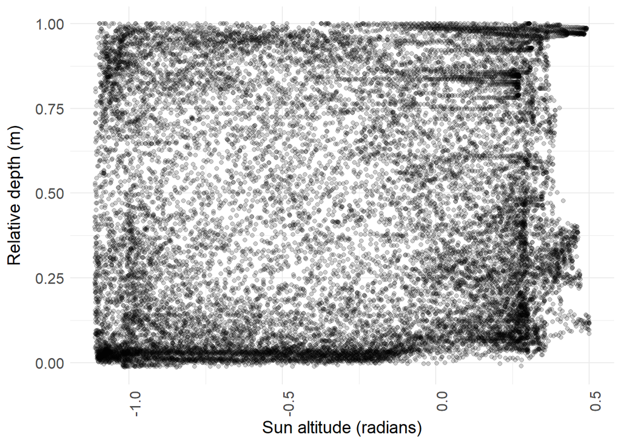

The relative depth over the sun altitude for 1 eel.

```r
ggplot(data_1eel, aes(x = sun_altitude,
                                   y = rel_depth)) +
  geom_point(alpha = 0.2) +
  theme_minimal() +
  ylab("Relative depth (m)") +
  xlab("Sun altitude (radians)") +
  theme(axis.title.y = element_text(margin = margin(r = 10))) +
  theme(axis.text.x = element_text(angle = 90, hjust = 1)) +
  theme(axis.text = element_text(size = 12),
        axis.title = element_text(size = 14))
```

### Plot detail relative depth pattern over sun altitude

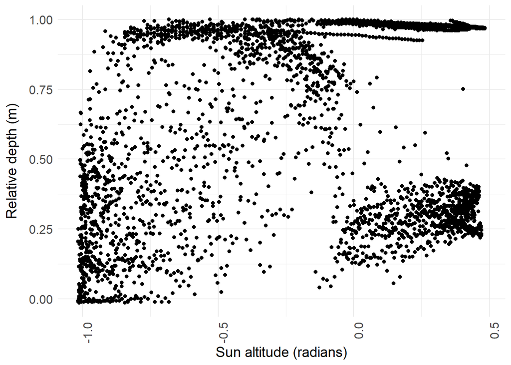

10-day detail of the relative depth over the sun altitude for 1 eel.

```r
ggplot(data_1eel_10days, aes(x = sun_altitude,
                                   y = rel_depth)) +
  geom_point() +
  theme_minimal() +
  ylab("Relative depth (m)") +
  xlab("Sun altitude (radians)") +
  theme(axis.title.y = element_text(margin = margin(r = 10))) +
  theme(axis.text.x = element_text(angle = 90, hjust = 1)) +
  theme(axis.text = element_text(size = 12),
        axis.title = element_text(size = 14))
```

### Plot relative depth pattern over sun class i.e. sunset or sunrise

```r
#plot(data_1eel$sun_altitude)
data_1eel$sun_class <- NA
for (i in 2:dim(data_1eel)[1]){
  if (data_1eel$sun_altitude[i] > data_1eel$sun_altitude[i-1]){
    data_1eel$sun_class[i] = "rising"
  } else{
    data_1eel$sun_class[i] = "setting"
  }}


data_1eel$sun_class <- factor(data_1eel$sun_class)
```

Note that there is not a big difference between sunrise and sunset because the depth range between day and night is equal, but the pattern is not. The NA is due to the first record of the dataset, for which a sun class could not be attributed according to the rule in the if-else loop.

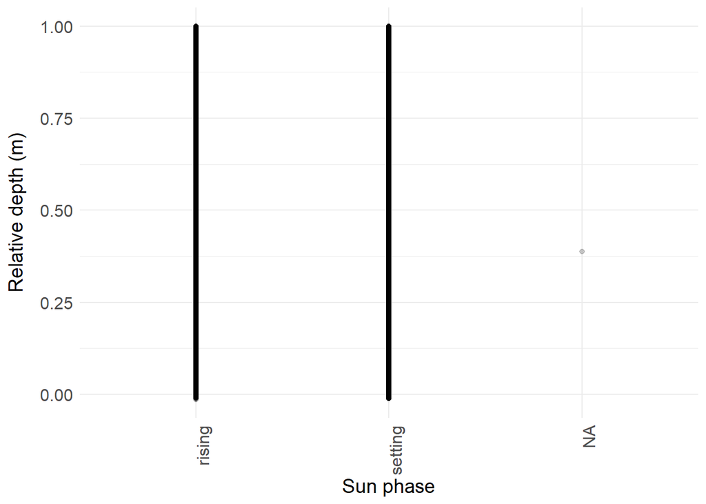

Relative depth over the two different sun classes (sunrise and sunset) for 1 eel.

```r
ggplot(data_1eel, aes(x = sun_class,
                                   y = rel_depth)) +
  geom_point(alpha = 0.2) +
  theme_minimal() +
  ylab("Relative depth (m)") +
  xlab("Sun phase") +
  theme(axis.title.y = element_text(margin = margin(r = 10))) +
  theme(axis.text.x = element_text(angle = 90, hjust = 1)) +
  theme(axis.text = element_text(size = 12),
        axis.title = element_text(size = 14))
```

### Plot relative depth pattern over sun azimuth

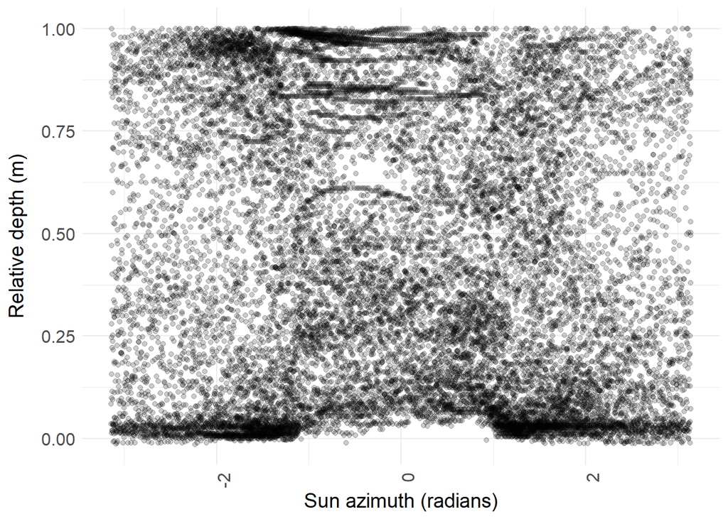

Relative depth over the sun azimuth for 1 eel.

```r
ggplot(data_1eel, aes(x = sun_azimuth,
                                   y = rel_depth)) +
  geom_point(alpha = 0.2) +
  theme_minimal() +
  ylab("Relative depth (m)") +
  xlab("Sun azimuth (radians)") +
  theme(axis.title.y = element_text(margin = margin(r = 10))) +
  theme(axis.text.x = element_text(angle = 90, hjust = 1)) +
  theme(axis.text = element_text(size = 12),
        axis.title = element_text(size = 14))
```

### Plot detail relative depth pattern over sun azimuth

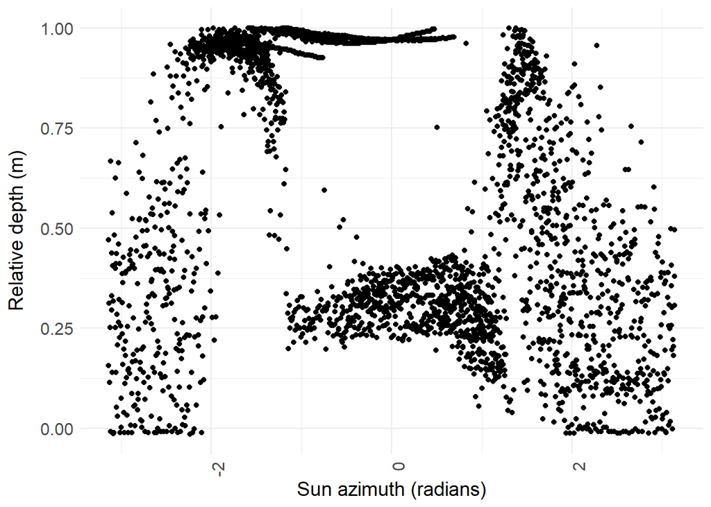

10-day detail of the relative depth over the sun azimuth for 1 eel.

```r
ggplot(data_1eel_10days, aes(x = sun_azimuth,
                                   y = rel_depth)) +
  geom_point() +
  theme_minimal() +
  ylab("Relative depth (m)") +
  xlab("Sun azimuth (radians)") +
  theme(axis.title.y = element_text(margin = margin(r = 10))) +
  theme(axis.text.x = element_text(angle = 90, hjust = 1)) +
  theme(axis.text = element_text(size = 12),
        axis.title = element_text(size = 14))
```

## Scale variables

For model construction, the exploratory variables need to be scaled. Max value should be between 0.5 - 5.

```r
# direction_x
summary(data_1eel$direction_x)
```

```
##    Min. 1st Qu.  Median    Mean 3rd Qu.    Max.    NA's
##  -1.756  -0.284   0.002   0.011   0.312   1.579    4332
```

```r
#iqr <- 0.312  - (-0.284 )   #3rd QU - 1st Qu
#data_1eel$direction_x_centre <- (data_1eel$direction_x - median(data_1eel$direction_x))/iqr

# direction_y
summary(data_1eel$direction_y)
```

```
##    Min. 1st Qu.  Median    Mean 3rd Qu.    Max.    NA's
##  -0.771  -0.172   0.007   0.015   0.199   1.017    4332
```

```r
#iqr <- 0.199 - (-0.172)   #3rd QU - 1st Qu
#data_1eel$direction_y_centre <- (data_1eel$direction_y - median(data_1eel$direction_y))/iqr

# Temperature
summary(data_1eel$temperature)
```

```
##    Min. 1st Qu.  Median    Mean 3rd Qu.    Max.
##   6.344   9.281   9.938   9.809  10.688  12.375
```

```r
#iqr <- 10.688  - (9.266 )   #3rd QU - 1st Qu
#data_1eel$temperature_centre <- (data_1eel$temperature - median(data_1eel$temperature))/iqr
data_1eel$temperature_scaled <- data_1eel$temperature / 10

# Moon illumination
summary(data_1eel$moon_fraction)
```

```
##      Min.   1st Qu.    Median      Mean   3rd Qu.      Max.
## 0.0001508 0.1299341 0.4100736 0.4585004 0.7963852 0.9999797
```

```r
#iqr <- 0.7966425   - (0.1311380)   #3rd QU - 1st Qu
#data_1eel$moon_fraction_centre <- (data_1eel$moon_fraction - median(data_1eel$moon_fraction))/iqr

# Sun altitude
summary(data_1eel$sun_altitude)
```

```
##    Min. 1st Qu.  Median    Mean 3rd Qu.    Max.
## -1.1107 -0.7703 -0.2729 -0.3103  0.1559  0.5006
```

```r
#iqr <- 0.1584   - (-0.7657)   #3rd QU - 1st Qu
#data_1eel$sun_altitude_centre <- (data_1eel$sun_altitude - median(data_1eel$sun_altitude))/iqr

# Sun azimuth
summary(data_1eel$sun_azimuth)
```

```
##       Min.    1st Qu.     Median       Mean    3rd Qu.       Max.
## -3.1400445 -1.3306698 -0.0000697  0.0006432  1.3316443  3.1411577
```

```r
#iqr <- 1.322311    - (-1.326227)   #3rd QU - 1st Qu
#data_1eel$sun_azimuth_centre <- (data_1eel$sun_azimuth - median(subset$sun_azimuth))/iqr
```

## Detrend the response variable

In case it would be needed, the response variable is detrended by subtracting a value by the previous value.

```r
data_1eel <- data_1eel %>%
  group_by(ID) %>%
  arrange(datetime) %>%
  mutate(diff_rel_depth = rel_depth - lag(rel_depth))
```

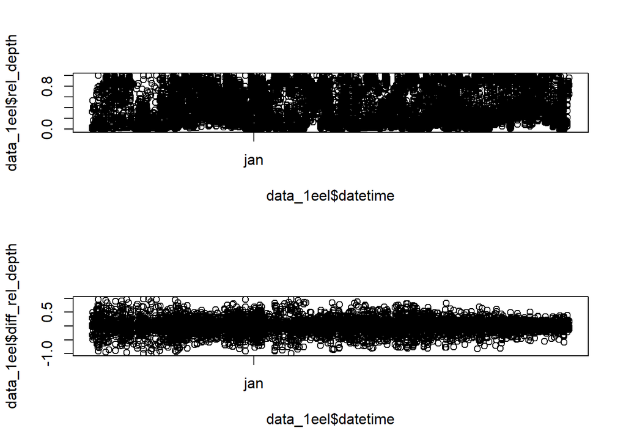

```r
par(mfrow=c(2,1))
plot(data_1eel$datetime, data_1eel$rel_depth)
plot(data_1eel$datetime, data_1eel$diff_rel_depth)
```

Check ACF & PACF plot if data is stationary

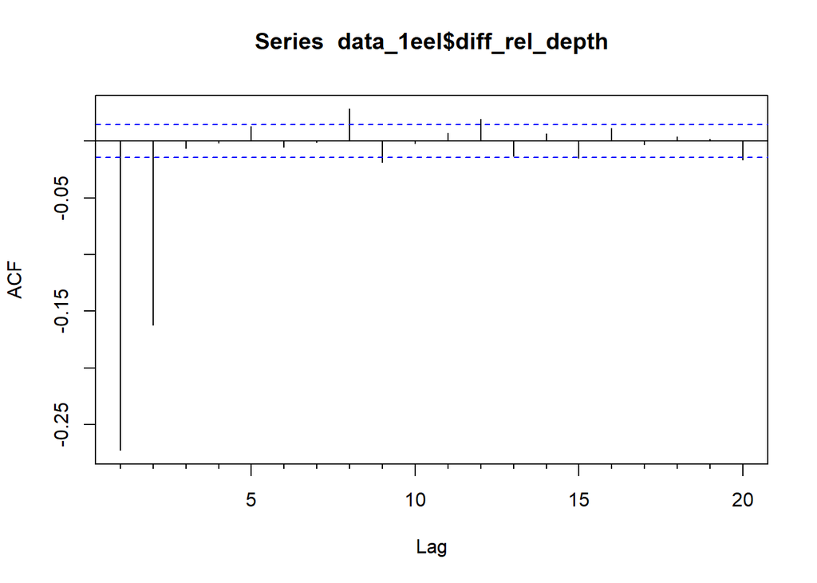

```r
forecast::Acf(data_1eel$diff_rel_depth, type = c("correlation"), lag.max=20, plot = TRUE)
```

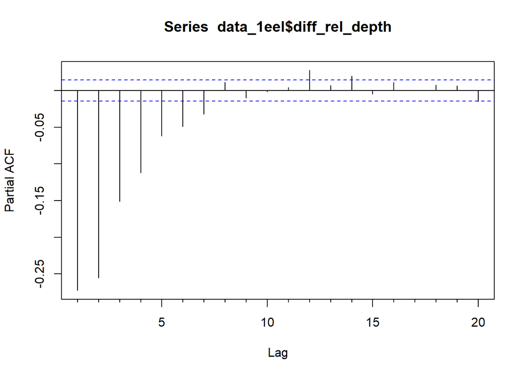

```r
forecast::Pacf(data_1eel$diff_rel_depth, lag.max=20, plot = TRUE)
```

## Conduct model on a subset of 5 eels

Next, a model was applied to a subset of 5 eels with a similar migration path (through the Channel). I want to apply this complex model first on only a few fish before scaling up the complexity.

### Load packages

```r
library(lme4)
library(glmmTMB)
```

### Subset 5 eels for testing

```r
data_5eels <- filter(data, ID == "16031" |
                   ID == "17535" |
                   ID == "17536" |
                   ID == "15777" |
                   ID == "17510")

data_5eels$ID <- factor(data_5eels$ID)
unique(data_5eels$ID)
```

```
## [1] 16031 15777 17510 17536 17535
## Levels: 15777 16031 17510 17535 17536
```

### Remove data from eel 17535 when it was in the Atlantic Ocean

For this study I am interested in the vertical movement behaviour on the contintental shelf. The vertical behaviour in oceanic conditions has already been described.

```r
data_5eels <- data_5eels[!(data_5eels$ID == "17535" & data_5eels$datetime > '2020-01-11 00:00:00'),]
```

### Depth data processing

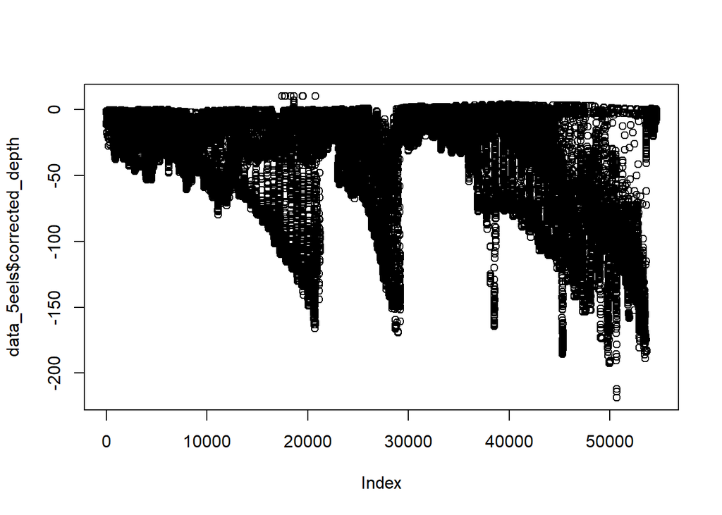

```r
plot(data_5eels$corrected_depth)
```

### Add daily max depth

```r
max_depth <- data_5eels %>%
  group_by(ID, Date) %>%
  summarise(max_depth = min(corrected_depth))
```

[output not shown]

```r
data_5eels <- left_join(data_5eels, max_depth, by = c("ID","Date"))
```